# Assignment 1

Anne Ioannides

17 February 2017

## Hello Octocat

I love Octocat. She’s the coolest cat in town.

[figure not shown]

# Assignment 2

```r
data("anscombe")
dim.data.frame(anscombe)
```

```
## [1] 11  8
```

```r
colnames(anscombe)
```

```
## [1] "x1" "x2" "x3" "x4" "y1" "y2" "y3" "y4"
```

```r
head(anscombe)
```

```
##   x1 x2 x3 x4   y1   y2    y3   y4
## 1 10 10 10  8 8.04 9.14  7.46 6.58
## 2  8  8  8  8 6.95 8.14  6.77 5.76
## 3 13 13 13  8 7.58 8.74 12.74 7.71
## 4  9  9  9  8 8.81 8.77  7.11 8.84
## 5 11 11 11  8 8.33 9.26  7.81 8.47
## 6 14 14 14  8 9.96 8.10  8.84 7.04
```

```r
tail(anscombe)
```

```
##    x1 x2 x3 x4    y1   y2   y3    y4
## 6  14 14 14  8  9.96 8.10 8.84  7.04
## 7   6  6  6  8  7.24 6.13 6.08  5.25
## 8   4  4  4 19  4.26 3.10 5.39 12.50
## 9  12 12 12  8 10.84 9.13 8.15  5.56
## 10  7  7  7  8  4.82 7.26 6.42  7.91
## 11  5  5  5  8  5.68 4.74 5.73  6.89
```

```r
summary(anscombe)
```

```
##        x1             x2             x3             x4
##  Min.   : 4.0   Min.   : 4.0   Min.   : 4.0   Min.   : 8
##  1st Qu.: 6.5   1st Qu.: 6.5   1st Qu.: 6.5   1st Qu.: 8
##  Median : 9.0   Median : 9.0   Median : 9.0   Median : 8
##  Mean   : 9.0   Mean   : 9.0   Mean   : 9.0   Mean   : 9
##  3rd Qu.:11.5   3rd Qu.:11.5   3rd Qu.:11.5   3rd Qu.: 8
##  Max.   :14.0   Max.   :14.0   Max.   :14.0   Max.   :19
##        y1               y2              y3              y4
##  Min.   : 4.260   Min.   :3.100   Min.   : 5.39   Min.   : 5.250
##  1st Qu.: 6.315   1st Qu.:6.695   1st Qu.: 6.25   1st Qu.: 6.170
##  Median : 7.580   Median :8.140   Median : 7.11   Median : 7.040
##  Mean   : 7.501   Mean   :7.501   Mean   : 7.50   Mean   : 7.501
##  3rd Qu.: 8.570   3rd Qu.:8.950   3rd Qu.: 7.98   3rd Qu.: 8.190
##  Max.   :10.840   Max.   :9.260   Max.   :12.74   Max.   :12.500
```

# Assignment 3

```
##    x1 x2 x3 x4    y1   y2    y3    y4
## 1  10 10 10  8  8.04 9.14  7.46  6.58
## 2   8  8  8  8  6.95 8.14  6.77  5.76
## 3  13 13 13  8  7.58 8.74 12.74  7.71
## 4   9  9  9  8  8.81 8.77  7.11  8.84
## 5  11 11 11  8  8.33 9.26  7.81  8.47
## 6  14 14 14  8  9.96 8.10  8.84  7.04
## 7   6  6  6  8  7.24 6.13  6.08  5.25
## 8   4  4  4 19  4.26 3.10  5.39 12.50
## 9  12 12 12  8 10.84 9.13  8.15  5.56
## 10  7  7  7  8  4.82 7.26  6.42  7.91
## 11  5  5  5  8  5.68 4.74  5.73  6.89
```

[figure not shown]

# Assignment 4

### Dataframe Setup

```r
#Here the data (analgesic) are imported from a csv file and structured as a dataframe, called df

df <- read.csv(file="https://dl.dropboxusercontent.com/u/11805474/painblogr/biostats/assignments/analgesic.csv", header=TRUE, sep=",")
```

### Dataframe Exploration

```r
#Data dimensions are defined:
dim(df)
```

```
## [1] 40  5
```

```r
#Column names of df are listed
colnames(df)
```

```
## [1] "ID"            "Group"         "Measurement_1" "Measurement_2"
## [5] "Measurement_3"
```

```r
#The first six rows of df are listed
head(df)
```

```
##   ID     Group Measurement_1 Measurement_2 Measurement_3
## 1  1 Analgesic            26            26            21
## 2  2 Analgesic            29            26            23
## 3  3 Analgesic            24            28            22
## 4  4 Analgesic            25            22            24
## 5  5 Analgesic            24            28            23
## 6  6 Analgesic            22            23            26
```

```r
#The last six rows of df are listed
tail(df)
```

```
##    ID   Group Measurement_1 Measurement_2 Measurement_3
## 35 35 Placebo            17            21            15
## 36 36 Placebo            19            17            15
## 37 37 Placebo            14            19            13
## 38 38 Placebo            17            19            13
## 39 39 Placebo            11            20            18
## 40 40 Placebo            15            18            12
```

```r
#Summary statistics (minimum, maximum, lower quartlile, median and upper quartile) for each column of df are listed
summary(df)
```

```
##        ID              Group    Measurement_1   Measurement_2
##  Min.   : 1.00   Analgesic:20   Min.   :10.00   Min.   : 8.0
##  1st Qu.:10.75   Placebo  :20   1st Qu.:17.00   1st Qu.:17.0
##  Median :20.50                  Median :20.00   Median :20.0
##  Mean   :20.50                  Mean   :20.12   Mean   :20.7
##  3rd Qu.:30.25                  3rd Qu.:24.00   3rd Qu.:25.0
##  Max.   :40.00                  Max.   :30.00   Max.   :32.0
##  Measurement_3
##  Min.   :12.00
##  1st Qu.:16.00
##  Median :20.50
##  Mean   :20.52
##  3rd Qu.:24.25
##  Max.   :30.00
```

### Data Tidying

```r
library(tidyr)
#Data are tidied using tidyr from wide to long format
df_long <- gather(df, ID, Group, Measurement_1:Measurement_3)

#Data are manipulated using dplyr
library(dplyr)
#The mean of each individual's measurements is calculated (summarised data)
summary(group_by(df_long, ID))
```

```
##        ID              Group         ID                Group
##  Min.   : 1.00   Analgesic:60   Length:120         Min.   : 8.00
##  1st Qu.:10.75   Placebo  :60   Class :character   1st Qu.:17.00
##  Median :20.50                  Mode  :character   Median :20.00
##  Mean   :20.50                                     Mean   :20.45
##  3rd Qu.:30.25                                     3rd Qu.:25.00
##  Max.   :40.00                                     Max.   :32.00
```

```r
#The dataframe is printed
print(df_long)
```

```
##     ID     Group            ID Group
## 1    1 Analgesic Measurement_1    26
## 2    2 Analgesic Measurement_1    29
## 3    3 Analgesic Measurement_1    24
## 4    4 Analgesic Measurement_1    25
## 5    5 Analgesic Measurement_1    24
## 6    6 Analgesic Measurement_1    22
## 7    7 Analgesic Measurement_1    25
## 8    8 Analgesic Measurement_1    28
## 9    9 Analgesic Measurement_1    22
## 10  10 Analgesic Measurement_1    18
## 11  11 Analgesic Measurement_1    25
## 12  12 Analgesic Measurement_1    26
## 13  13 Analgesic Measurement_1    26
## 14  14 Analgesic Measurement_1    19
```

[output cut: 106 more lines]

# Assignment 5

### Chicken Weights

**Hypotheses**  
*Null Hypothesis:* No difference exists between the weights of chickens consuming different feed types  
*Alternative Hypothesis:* A difference exists between the weights of chickens consuming different feed types

**Statistical Test Details**  
*Test Statistic:*  
Kruskal-Wallis rank sum rest  
*Assumptions:*  
The errors are independent  
Data are unmatched  
Samples are drawn from populations with the same shape distributions  
Samples are drawn from the population are random  
Observations are independent of each other  
Measured scale for the dependent variable is ordinal

```r
chicken_weights <- read.csv(file = "https://dl.dropboxusercontent.com/u/11805474/painblogr/biostats/assignments/chick-weights.csv?dl=1", header=TRUE, sep=",")

print(chicken_weights)
```

```
##    weight      feed
## 1     179 horsebean
## 2     160 horsebean
## 3     136 horsebean
## 4     227 horsebean
## 5     217 horsebean
## 6     168 horsebean
## 7     108 horsebean
## 8     124 horsebean
## 9     143 horsebean
## 10    140 horsebean
## 11    309   linseed
## 12    229   linseed
## 13    181   linseed
## 14    141   linseed
```

[output cut: 57 more lines]

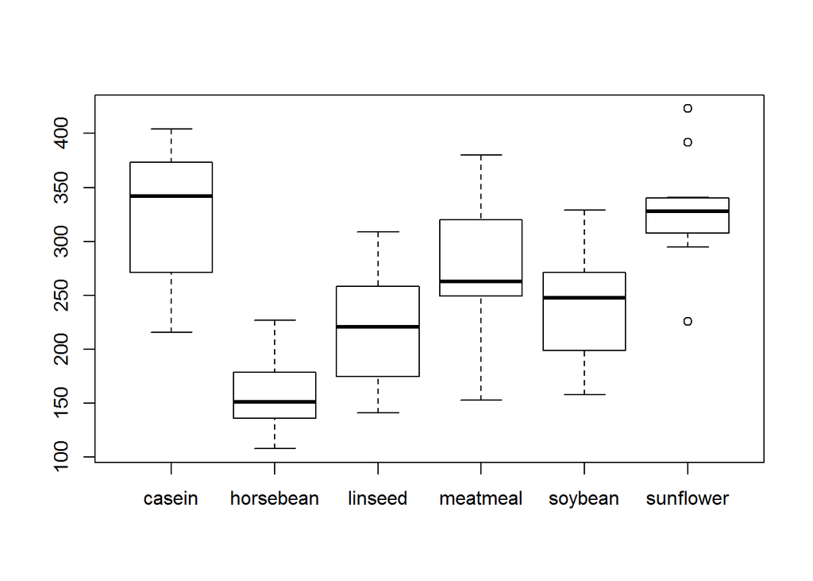

```r
#Plot-based exploration
boxplot(chicken_weights$weight ~ chicken_weights$feed)
```

```r
#Kruskal-Wallis Test
kruskal.test(weight ~ feed,
             data = chicken_weights)
```

```
##
##  Kruskal-Wallis rank sum test
##
## data:  weight by feed
## Kruskal-Wallis chi-squared = 37.343, df = 5, p-value = 5.113e-07
```

```r
#Post-hoc test with Holm correction
pairwise.t.test(chicken_weights$weight, chicken_weights$feed, p.adjust.method = "holm", paired = FALSE)
```

```
##
##  Pairwise comparisons using t tests with pooled SD
##
## data:  chicken_weights$weight and chicken_weights$feed
##
##           casein  horsebean linseed meatmeal soybean
## horsebean 2.9e-08 -         -       -        -
## linseed   0.00016 0.09435   -       -        -
## meatmeal  0.18227 9.0e-05   0.09435 -        -
## soybean   0.00532 0.00298   0.51766 0.51766  -
## sunflower 0.81249 1.2e-08   8.1e-05 0.13218  0.00298
##
## P value adjustment method: holm
```

*Interpretation:*  
The Kruskal Wallis test showed that the weights of the chickens did differ based on their chicken feed (X^2 = 37.343, df = 5, p < 0.0001).  
Post-hoc tests revealed that casein lead to significantly greater weight gain than horsebean (p < 0.0001), linseed (p = 0.0002) and soybean (p = 0.0053) but not meatmeal (p = 0.1823) or sunflower (p = 0.8125).

Horsebean feed yielded the lowest weight, where weight was significantly lower than meatmeal (p < 0.0001), soybean (p = 0.003) and sunflower (p < 0.0001) but not significantly lower than weights yielded by linseed (p = 0.0944).

Linseed was only found to have a significantly higher weight gain than horsebean (as reported above) but a significantly lower weight than sunflower (p < 0.0001) but not to meatmeal (p = 0.0944) or soybean (p = 0.5177).

Meatmeal feed was not not found to influence weight any more significantly than casein, linseed (as reported above), soybean (p = 0.5177) or sunflower (p = 0.1322). Horsebean was found to yield significantly lower weights (as reported above).

Soybean was found to yield significantly lighter chickens than casein (as reported above) and sunflower (p = 0.003), but significantly heavier chickens than horsebean (as reported above). There was no statistically significant difference between weights of chickens fed linseed or meatmeal compared to soybean.

### Hot Zone

**Hypotheses**  
*Null Hypothesis:* No difference between individuals’ illness outcomes exists as a consequence of their water consumption  
*Alternative Hypothesis:* A difference between individuals’ illness outcomes exists as a consequence of their water consumption

**Statistical Test Details**  
*Test Statistic:*  
Cochran-Mantel-Haenszel Test  
*Assumptions:*  
The Odds Ratio is the same in different repeats of the experiment

```r
hot_zone <- read.csv(file = "https://dl.dropboxusercontent.com/u/11805474/painblogr/biostats/assignments/gastroenteritis.csv?dl=1", header=TRUE, sep=",")

#I initially printed the raw hot_zone data for view and decided on the data type

#Data are categorical but ordinal in nature, therefore data are cross-tabulated
xtabs(~Outcome + Consumption, data = hot_zone)
```

```
##          Consumption
## Outcome   < 1 glasses/day > 4 glasses/day 1 to 4 glasses/day
##   ill                  39             265                265
##   not ill             121             146                258
```

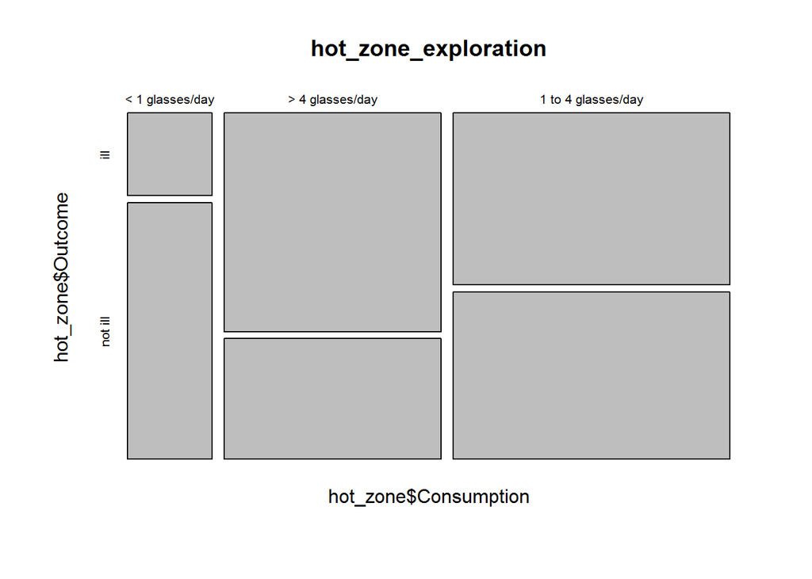

```r
#Plot-based exploration of data
#A mosaic plot is elected for best visualisation

hot_zone_exploration <- xtabs(~ hot_zone$Consumption + hot_zone$Outcome)

mosaicplot(hot_zone_exploration)

#Due to the data being ordinal, data are assigned scores (where the vcdExtra package is required)
library(vcdExtra)
```

```r
#Scores are assigned as 1, 3, 2 (and not 1, 2, 3) as the second column is "> 4 glasses" and the last column is "1 - 4 glasses"
CMHtest(hot_zone_exploration,
        types = "cmeans",
        cscores = c(1, 3, 2))
```

```
## Cochran-Mantel-Haenszel Statistics for hot_zone$Consumption by hot_zone$Outcome
##
##                 AltHypothesis  Chisq Df      Prob
## cmeans Col mean scores differ 9.8467  1 0.0017013
```

```r
detach(package: vcdExtra)
```

*Interpretation:*  
The more water consumed by individuals, the more likely they were to become ill (X^2 = 9.8467, df = 1, p = 0.0017).

### Nausea

**Hypotheses**  
*Null Hypothesis:* No difference exists between nausea ratings before and after consumption of the 5HT3-receptor blocker  
*Alternative Hypothesis:* A difference between nausea ratings before and after consumption of the 5HT3-receptor blocker exists

**Statistical Test Details**  
*Test Statistic:*  
Wilcoxon signed-rank test  
*Assumptions:*  
The errors are independent  
Matching is effective  
Samples are drawn from populations with the same shape distributions

```r
nausea <- read.csv(file = "https://dl.dropboxusercontent.com/u/11805474/painblogr/biostats/assignments/nausea.csv?dl=1", header=TRUE, sep=",")

print(nausea)
```

```
##   Patient Nausea_before Nausea_after
## 1       1             3            2
## 2       2             4            0
## 3       3             6            1
## 4       4             2            3
## 5       5             2            1
## 6       6             4            1
## 7       7             5            0
## 8       8             6           40
```

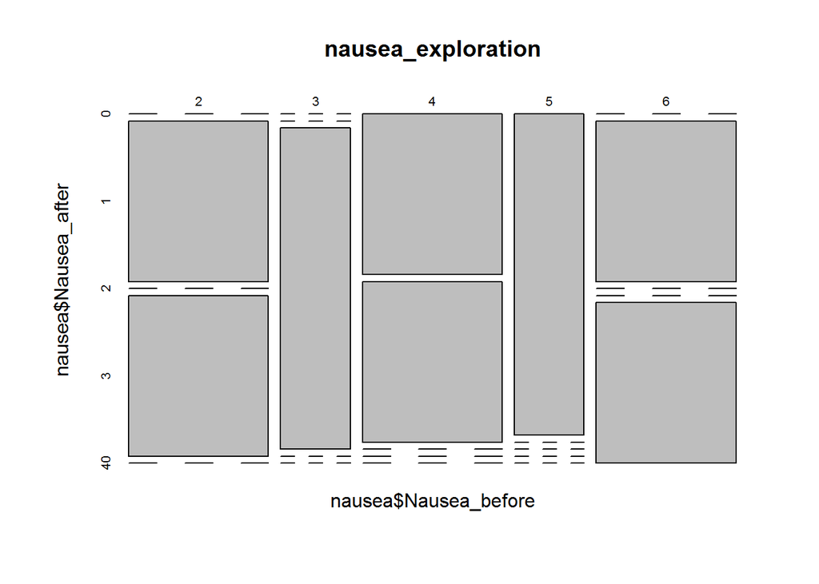

```r
#Plot-based exploration
nausea_exploration <- xtabs(~ nausea$Nausea_before + nausea$Nausea_after)

mosaicplot(nausea_exploration)
```

```r
library(tidyr)

#nausea_long <- gather(nausea, Nausea_before:Nausea_after)
#print(nausea_long)

library(dplyr)

summary(nausea)
```

```
##     Patient     Nausea_before   Nausea_after
##  Min.   :1.00   Min.   :2.00   Min.   : 0.00
##  1st Qu.:2.75   1st Qu.:2.75   1st Qu.: 0.75
##  Median :4.50   Median :4.00   Median : 1.00
##  Mean   :4.50   Mean   :4.00   Mean   : 6.00
##  3rd Qu.:6.25   3rd Qu.:5.25   3rd Qu.: 2.25
##  Max.   :8.00   Max.   :6.00   Max.   :40.00
```

```r
wilcox.test(nausea$Nausea_before, nausea$Nausea_after,
            paired = TRUE)
```

```
##
##  Wilcoxon signed rank test with continuity correction
##
## data:  nausea$Nausea_before and nausea$Nausea_after
## V = 26, p-value = 0.2906
## alternative hypothesis: true location shift is not equal to 0
```

*Interpretation:*  
There is no difference between the nausea ratings in patients before and after they took the 5HT3-receptor blocker (V = 26, p = 0.2906).

# Assignment 6

### Housing Prices

**Hypotheses**  
*Null Hypothesis:*  
No relationship exists between the interest rate and the median house price in USD  
*Alternative Hypothesis:*  
A linear relationship exists between the interest rate and the median house price in USD

**Statistical Test Details**  
*Test Statistic:* Linear Regression

*Assumptions:*  
A linear regression exists between interest rate and the median house price in USD  
Observations are independent (impaired)  
Interest rate is measured without error  
Residuals (distance from the regression line) are normally distributed  
Residuals have the same variance for all fitted values of the median house price (i.e. they are homoscedastic, where no relationship is seen between the interest rate and the size of the residual)

```r
housing_prices <- read.csv(file = "https://dl.dropboxusercontent.com/u/11805474/painblogr/biostats/assignments/housing-prices.csv?dl=1", header=TRUE, sep=",")

#I printed the data to see what they looked like
print(housing_prices)
```

```
##    interest_rate median_house_price_USD
## 1             10                 183800
## 2             10                 183200
## 3             10                 174900
## 4              9                 173500
## 5              8                 172900
## 6              7                 173200
## 7              8                 173200
## 8              8                 169700
## 9              8                 174500
## 10             8                 177900
## 11             7                 188100
## 12             7                 203200
## 13             8                 230200
## 14             7                 258200
## 15             7                 309800
## 16             6                 329800
## 17            NA                     NA
```

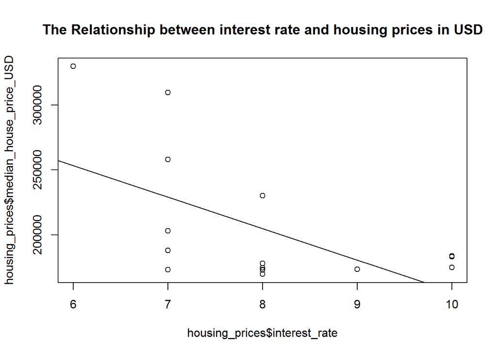

```r
library(ggplot2)

#I used exploratory plots
plot(housing_prices$interest_rate, housing_prices$median_house_price_USD,
     main = "The Relationship between interest rate and housing prices in USD",
     abline(lm(housing_prices$median_house_price_USD ~ housing_prices$interest_rate,
               data = housing_prices,
               lwd = 3,
               col = 4)))
```

```r
#Linear Regression
housing_regression <- lm(housing_prices$median_house_price_USD ~ housing_prices$interest_rate,
                         data = housing_prices)

summary(housing_regression)
```

```
##
## Call:
## lm(formula = housing_prices$median_house_price_USD ~ housing_prices$interest_rate,
##     data = housing_prices)
##
## Residuals:
##    Min     1Q Median     3Q    Max
## -55865 -31631 -16406  27212  80735
##
## Coefficients:
##                              Estimate Std. Error t value Pr(>|t|)
## (Intercept)                    399229      74427   5.364 9.99e-05 ***
## housing_prices$interest_rate   -24309       9205  -2.641   0.0194 *
## ---
## Signif. codes:  0 '***' 0.001 '**' 0.01 '*' 0.05 '.' 0.1 ' ' 1
##
## Residual standard error: 43180 on 14 degrees of freedom
##   (1 observation deleted due to missingness)
## Multiple R-squared:  0.3325, Adjusted R-squared:  0.2848
## F-statistic: 6.974 on 1 and 14 DF,  p-value: 0.01937
```

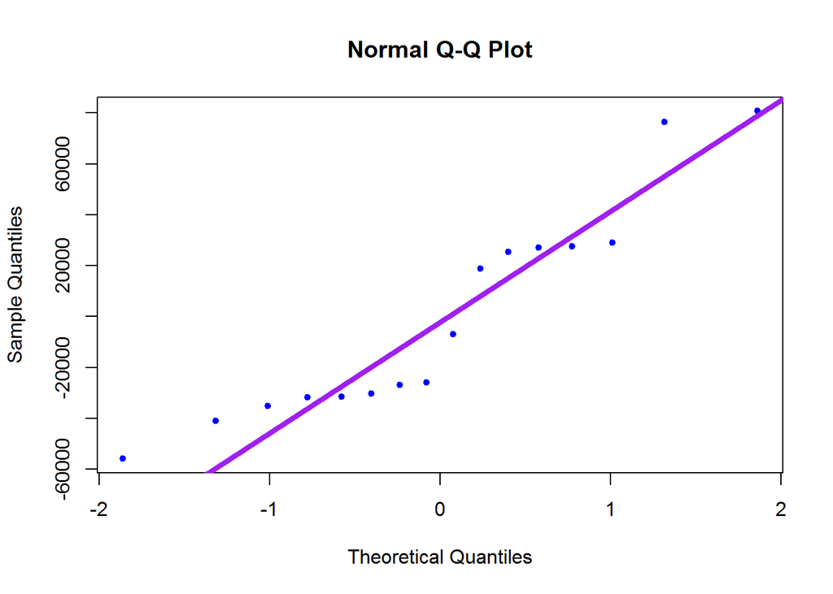

```r
#Appropriate Diagnostic Criteria:
#1. Residuals follow Normal Distribution
qqnorm(housing_regression$residuals,
       pch = 20,
       col = "blue") #Because blue is my favourite colour
qqline(housing_regression$residuals,
       lwd = 4,
       col = "purple")
```

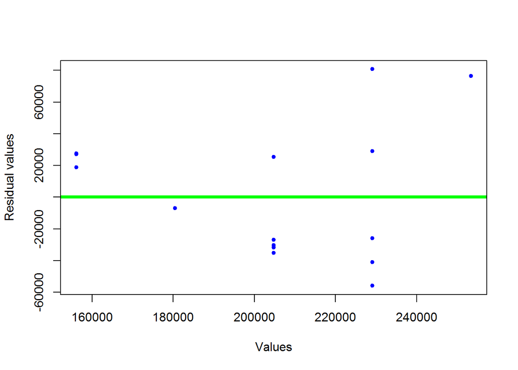

```r
#2. Homoskedasticity
plot(x = housing_regression$fitted.values,
     y = housing_regression$residuals,
     xlab = "Values",
     ylab = "Residual values",
     pch = 20,
     col = 4,
     abline(h = 0,
            lwd = 4,
            col = "green"))
```

```r
#Plotting the linear model
glm(housing_prices$median_house_price_USD ~ housing_prices$interest_rate,
    data = housing_prices)
```

```
##
## Call:  glm(formula = housing_prices$median_house_price_USD ~ housing_prices$interest_rate,
##     data = housing_prices)
##
## Coefficients:
##                  (Intercept)  housing_prices$interest_rate
##                       399229                        -24309
##
## Degrees of Freedom: 15 Total (i.e. Null);  14 Residual
##   (1 observation deleted due to missingness)
## Null Deviance:       3.91e+10
## Residual Deviance: 2.61e+10  AIC: 390.8
```